# Technical Note: Extension of the GSED2510 D-score Model with DDI/Van Wiechen Items

Author

Iris Eekhout

Published

July 2, 2026

# Purpose of this Technical Note

This technical note describes the steps taken to extend the existing **GSED2510 D-score model** with Dutch DDI/Van Wiechen items. The purpose of this extension is to estimate item parameters for Van Wiechen/DDI items on the most recent GSED2510 metric, allowing Dutch preventive child healthcare (JGZ) data to be consistently converted into D-scores.

This note serves as technical documentation for future projects in which the D-score will be applied within Dutch preventive child healthcare practice.

# Background and Motivation

The D-score provides a common scale for measuring early childhood development. To support its application within Dutch preventive child healthcare, it is necessary to link the Van Wiechen assessment / DDI instrument to the most recent GSED calibration. Previous analyses were based on an earlier D-score calibration. However, further development of guidelines, normative references, and monitoring dashboards requires an update to the latest GSED2510 metric.

The current work therefore focuses on extending the GSED2510 model with DDI items. Items that already have a direct correspondence with GSED items are used as fixed anchor parameters. For the remaining DDI items, new item parameters are estimated using available Dutch and additional DDI data.

# Data Sources

## Source Data

For this model extension, DDI/Van Wiechen data were retrieved from the `gseddata` package. The data consist of longitudinal item responses collected from children at different ages.

The analysis uses:

- DDI/Van Wiechen item responses;
- age in days (`agedays`);
- subject identifier (`subjid`);
- cohort information;
- country code;
- measurement occasion information.

## Inclusion of Additional DDI Cohorts

The script is configured to include additional DDI cohorts from `gseddata::gsed_lean`:

**Show/hide R-code**

```r
include_extra_ddi_cohorts <- TRUE
```

The raw item data are restricted to binary responses:

`pad$itm <- dplyr::filter(pad$itm, value %in% c(0, 1))`

# Data Preparation

## Long-Format Dataset

The DDI item responses are first assembled in long format by linking item-level data to visit information based on `subjid` and `agedays`. The following variables are retained:

- `cohort`;
- `country`;
- `subjid`;
- `agedays`;
- `pair`;
- `ins`;
- `item`;
- `response`.

**Show/hide R-code**

```r
items_ddi <- dscore::get_itemnames(ins = "ddi")

pad <- gseddata::get_data(adm = ".", items = items_ddi, min_cat = 10)
pad$itm <- dplyr::filter(pad$itm, value %in% c(0, 1))

long <- dplyr::left_join(
  pad$itm,
  pad$visit,
  by = c("subjid", "agedays")
) |>
  dplyr::mutate(
    subjid = as.character(subjid),
    ins = "DDI",
    pair = agedays
  ) |>
  dplyr::select(
    cohort,
    country = ctrycd,
    subjid,
    agedays,
    pair,
    ins,
    item,
    response = value
  )
```

## Wide-Format Dataset

For fitting the D-score model, the dataset is transformed into wide format: one row per child-assessment occasion, with item responses represented as columns.

**Show/hide R-code**

```r
dat <- long |>
  tidyr::pivot_wider(
    id_cols = c(cohort, country, subjid, agedays, pair, ins),
    names_from = item,
    values_from = response
  ) |>
  dplyr::arrange(subjid, agedays)
```

# Linking to Existing GSED2510 Item Parameters

## Identifying DDI Items Already Present in GSED

A subset of the DDI items is directly linked to existing GSED items. These items can be used as anchors because item parameters are already available from the GSED2510 model.

**Show/hide R-code**

```r
ddi_in_gsed <- dscore::builtin_translate |>
  dplyr::filter(grepl("^ddi", gsed)) |>
  dplyr::mutate(tau = get_tau(gsed3))
ddi_in_gsed |> select(gsed, gsed3, label, tau) |>
  left_join(dscore::builtin_itemtable, by = c("gsed" = "item")) |> kable()
```

| gsed | gsed3 | label.x | tau | equate | label.y |
| --- | --- | --- | --- | --- | --- |
| ddigmd057 | gl1gmd004 | A4 Lifts head in prone 45 degrees (2X) | 18.32 | GM12 | Lifts head to 45 degrees on prone position |
| ddigmd061 | gl1gmd010 | A10 Balances head while supported | 18.73 | NA | Balances head well while sitting |
| ddifmd010 | gl1gmd027 | A27 Picks up small object between thumb and finger (2X) | 38.28 | FM26 | Picks up pellet between thumb and index finger |
| ddifmm012 | gl1gmd030 | “A30 Plays”“give-and-take”” (3X)” | 48.37 | NA | “Plays ‘give and take’ (M; can ask parents)” |
| ddicmm029 | gl1lgd002 | B2 Reacts when spoken to (2X) | 8.56 | REC50 | Reacts when spoken to |
| ddicmm030 | gl1lgd003 | B3 Smiles in response (2X) | 13.40 | NA | “Smiles in response (M; can ask parents)” |
| ddicmm034 | gl1lgd008 | B8 Babbles while playing | NA | EXP12 | Babbles while playing |
| ddicmd141 | gl1lgd018 | B18 Identifies 2 objects you name (2X) | 56.51 | NA | Identifies two named objects |
| ddicmd044 | gl1lgd023 | B23 Points at 5 pictures in book | 61.92 | NA | Points at 5 pictures in the book |
| ddicmm041 | gl1lgd026 | B26 Says sentences with 2 words together | 63.75 | EXP26 | Says sentences with 2 words |
| ddicmm047 | gl1lgd043 | B43 Talks easily about daily events | 74.41 | NA | “Talks spontaneously on daily events (M; can ask parents)” |
| ddifmd001 | gl1fmd001 | C1 Fixates eyes (2X) | 7.17 | COG3 | Eyes fixate |
| ddifmd013 | gl1fmd026 | C26 Builds tower of 2 blocks (2X) | 55.02 | FM31 | Tower of 2 cubes |
| ddifmd023 | gl1fmd045 | C45 Imitates building bridge (2X) | 74.04 | FM52 | Imitates building a bridge |
| ddifmd026 | gl1fmd047 | C47 Copies a circle | 74.97 | FM43 | Copies a circle |

## Loading the Existing GSED2510 Model

The existing GSED2510 Rasch model is loaded from a locally stored RDS file.

**Show/hide R-code**

```r
modelgsed2510 <- readRDS("C:/Users/eekhouti/OneDrive - TNO/Projecten/gsed/Phase 2/202510/281_0_phase_1+2/model.Rds")
```

## Deriving Fixed Item Parameters

The beta parameters from the existing model are converted to tau parameters. Item names are translated from GSED to DDI nomenclature when needed. The DDI items present in the wide-format dataset are then selected as fixed parameters.

**Show/hide R-code**

```r
fixed_gsd <- -modelgsed2510$fit$betapar
lookup <- setNames(ddi_in_gsed$gsed, ddi_in_gsed$gsed3)

new_names <- ifelse(
  names(fixed_gsd) %in% names(lookup),
  lookup[names(fixed_gsd)],
  names(fixed_gsd)
)

names(fixed_gsd) <- new_names

ddi_fixed <- fixed_gsd[names(fixed_gsd) %in% names(dat)]
```

# Item Selection and Quality Control

Before model fitting, several checks were performed to determine which DDI items contained sufficient information for estimation. *Note that in the loaded data from `gseddata` the quality checks and cleaning was already performed so code is presented here for completeness of process.*

## Selection of DDI Items

**Show/hide R-code**

```r
items <- dat |>
  dplyr::select(dplyr::starts_with("ddi")) |>
  colnames()
```

## Check 1: Minimum Number of Valid Responses

Items with fewer than 10 valid responses are excluded. In the current analysis, no items were removed based on this criterion.

**Show/hide R-code**

```r
nvalid <- colSums(!is.na(dat[, items]))
sum(nvalid < 10)
```

```
[1] 0
```

**Show/hide R-code**

```r
items[nvalid < 10]
```

```
character(0)
```

**Show/hide R-code**

```r
items <- items[nvalid >= 10]
```

## Check 2: Minimum Number of Responses in the Least Frequent Category

Items are retained only when both response categories occur sufficiently often. In the current analysis, no items were removed based on this criterion.

**Show/hide R-code**

```r
keep <- sapply(dat[, items], function(x) min(table(x)) >= 10)
sum(!keep)
```

```
[1] 0
```

**Show/hide R-code**

```r
names(keep[!keep])
```

```
character(0)
```

**Show/hide R-code**

```r
items <- items[keep]
```

## Check 3: Sufficient Variability

Items without sufficient variability are excluded. A standard deviation threshold of 0.01 was applied. In the current analysis, no items were removed based on this criterion.

**Show/hide R-code**

```r
keep <- sapply(dat[, items], function(x) sd(x, na.rm = TRUE) > 0.01)
sum(!keep)
```

```
[1] 0
```

**Show/hide R-code**

```r
names(keep[!keep])
```

```
character(0)
```

**Show/hide R-code**

```r
items <- items[keep]
```

# Preparation for Model Fitting

The final model dataset contains the selected DDI items and administrative variables.

**Show/hide R-code**

```r
data <- dat |>
  dplyr::select(dplyr::all_of(items), subjid, agedays, cohort, country)

varlist <- list(
  adm = c("subjid", "agedays", "cohort", "country"),
  items = items
)
```

The following arguments are critically important in `fit_dmodel`:

- `anchors`
- `data_package`
- `transform`

## Anchors

We can define two anchor items that are used to align the scaling of the new model to the existing metric. Two items are selected (arbitrarily) that both have fixed GSED parameters (beta and tau).

**Show/hide R-code**

```r
#modelgsed2510$itembank %>% filter(item %in%  names(lookup))
anchors <- modelgsed2510$itembank %>% filter(item %in%  c("gl1fmd026", "gl1lgd026")) %>% dplyr::select(tau) %>% unlist
anchor_names <- ifelse(c("gl1fmd026", "gl1lgd026") %in% names(lookup),
                    lookup[c("gl1fmd026", "gl1lgd026")],
                    names(fixed_gsd))
names(anchors) <- anchor_names
names(anchors) %in% names(data)
```

```
[1] TRUE TRUE
```

*Note: omitting anchors yields a different solution if no additional adjustments are made through `data_package` and `transform`; see also `scripts/model_ddi2510_anchor_comp.R`.*

## Transform

Using the intercept and slope from `model$transform` is a cleaner and preferred solution compared with using anchor items. However, in that case the `data_package` argument must explicitly be specified as `""`; otherwise the transform parameters may be overwritten.

**Conclusion: we supply `transform = modelgsed2510$transform` together with `data_package = ""`. This provides a robust solution that is independent of which anchor items are available in the data.**

# Model Estimation (1)

The DDI extension model is fitted using `dmetric::fit_dmodel()`. All available fixed DDI/GSED parameters are used to link new DDI items to the GSED2510 model and transform coefficients are used to transform to the GSED2510 scale.

**Show/hide R-code**

```r
i <- length(varlist$items)
f <- length(ddi_fixed)
model_name <- paste("ddi", i, f, sep = "_")
model_name
```

```
[1] "ddi_74_14"
```

**Show/hide R-code**

```r
model <- dmetric::fit_dmodel(
  data = data,
  varlist = varlist,
  name = model_name,
  b_fixed = ddi_fixed,
  data_package = "",
  transform = modelgsed2510$transform
)
```

# Model Diagnostics (1)

## Item Fit of Fixed Items

The first step is to evaluate items with fixed GSED parameters for potential misfit.

**Show/hide R-code**

```r
model$item_fit |>
  dplyr::filter((outfit > 1 | infit > 1) & item %in% names(ddi_fixed))
```

```
# A tibble: 4 × 8
  item          n outfit     qo outfit_z infit     qi infit_z
  <chr>     <int>  <dbl>  <dbl>    <dbl> <dbl>  <dbl>   <dbl>
1 ddicmd044  3226  0.775 0.0918   -2.63   1.15 0.0373    3.89
2 ddifmd010  3236  1.07  0.0832    0.875  1.14 0.0282    4.70
3 ddifmd013  2949  0.906 0.0465   -2.08   1.03 0.0210    1.25
4 ddigmd061  3465  2.15  0.146     6.05   4.04 0.0959   18.6
```

> The results indicate that the fixed model parameter for item `ddigmd061` does not fit the observed data. Therefore, we decide to release this item and re-estimate its parameter in a new model.

Compare the fit statistics of the fixed items with the corresponding item fit statistics in the GSED2510 model. Ideally, infit and outfit values should be comparable across models.

**Show/hide R-code**

```r
model$item_fit |> select(item, n, outfit, infit) |> filter(item %in% names(ddi_fixed)) |>
  left_join(ddi_in_gsed, by = c("item"="gsed")) |> select(item:infit, gsed3) |>
  left_join({modelgsed2510$item_fit |> select(item, n, outfit, infit)}, by= c("gsed3" = "item"))
```

```
# A tibble: 14 × 8
   item        n.x outfit.x infit.x gsed3       n.y outfit.y infit.y
   <chr>     <int>    <dbl>   <dbl> <chr>     <int>    <dbl>   <dbl>
 1 ddicmm029  1984    0.263   0.305 gl1lgd002  2310    0.822   0.949
 2 ddicmm030  3513    0.502   0.632 gl1lgd003  2934    0.701   0.936
 3 ddicmm041  4224    0.579   0.694 gl1lgd026  2446    0.760   0.824
 4 ddicmd044  3226    0.775   1.15  gl1lgd023  2381    0.913   0.917
 5 ddicmm047  2232    0.475   0.648 gl1lgd043  2467    0.852   0.899
 6 ddicmd141  2883    0.689   0.779 gl1lgd018  2398    0.786   0.845
 7 ddifmd001  1971    0.340   0.557 gl1fmd001  2940    0.946   0.848
 8 ddifmd010  3236    1.07    1.14  gl1gmd027  2172    1.02    0.924
 9 ddifmm012  3344    0.467   0.610 gl1gmd030  2612    1.13    0.949
10 ddifmd013  2949    0.906   1.03  gl1fmd026  2354    0.908   0.938
11 ddifmd023  2183    0.604   0.828 gl1fmd045  2824    0.816   0.875
12 ddifmd026  2327    0.543   0.751 gl1fmd047  1983    1.01    1.00
13 ddigmd057  2662    0.692   0.769 gl1gmd004  2902    0.704   0.834
14 ddigmd061  3465    2.15    4.04  gl1gmd010  2495    0.921   0.968
```

## Parameter Estimates of Fixed Items

By fixing the parameters of DDI items that are directly linked to GSED items, the DDI item estimates become aligned with the core GSED2510 model. We additionally verify that the estimated tau (D-score) parameters of the fixed items correspond exactly to those of the matching items in the GSED2510 core model.

*Because these values are imposed during estimation, this serves primarily as a verification that the model settings have been correctly applied.*

**Show/hide R-code**

```r
fix_tau <- ddi_in_gsed |> select(gsed, gsed3, tau) |> rename(item = gsed) |> arrange(tau)
model_tau <- model$itembank |> filter(item %in% ddi_in_gsed$gsed) |> select(item, tau) |> rename(tau_est = tau) |> arrange(tau_est) |> mutate(tau_est = round(tau_est,2))
fix_tau |> left_join(model_tau, by = "item")
```

```
        item     gsed3   tau tau_est
1  ddifmd001 gl1fmd001  7.17    7.17
2  ddicmm029 gl1lgd002  8.56    8.56
3  ddicmm030 gl1lgd003 13.40   13.40
4  ddigmd057 gl1gmd004 18.32   18.32
5  ddigmd061 gl1gmd010 18.73   18.73
6  ddifmd010 gl1gmd027 38.28   38.28
7  ddifmm012 gl1gmd030 48.37   48.37
8  ddifmd013 gl1fmd026 55.02   55.02
9  ddicmd141 gl1lgd018 56.51   56.51
10 ddicmd044 gl1lgd023 61.92   61.92
11 ddicmm041 gl1lgd026 63.75   63.75
12 ddifmd023 gl1fmd045 74.04   74.04
13 ddicmm047 gl1lgd043 74.41   74.41
14 ddifmd026 gl1fmd047 74.97   74.97
15 ddicmm034 gl1lgd008    NA   36.65
```

## Releasing Fixed Parameters

In principle, DDI items that are directly linked to GSED2510 items are included as fixed parameters. However, during the analysis it became apparent that the fixed-parameter specification for item `ddigmd061` was inconsistent with the observed data. Therefore, the fixed parameter for this item was removed and re-estimated freely.

**Show/hide R-code**

```r
ddi_fixed <- ddi_fixed[setdiff(names(ddi_fixed), "ddigmd061")]
```

# Model Estimation (2)

The DDI extension model is fitted using `dmetric::fit_dmodel()`. Filtered fixed DDI/GSED parameters are used to link new DDI items to the GSED2510 model and transform coefficients are used to transform to the GSED2510 scale.

**Show/hide R-code**

```r
i <- length(varlist$items)
f <- length(ddi_fixed)
model_name <- paste("ddi", i, f, sep = "_")
model_name
```

```
[1] "ddi_74_13"
```

**Show/hide R-code**

```r
model <- dmetric::fit_dmodel(
  data = data,
  varlist = varlist,
  name = model_name,
  b_fixed = ddi_fixed,
  data_package = "",
  transform = modelgsed2510$transform
  )
```

# Model Diagnostics (2)

## Item Fit of fixed items

The first step is to evaluate items with fixed GSED parameters for potential misfit.

**Show/hide R-code**

```r
model$item_fit |>
  dplyr::filter((outfit > 1 | infit > 1) & item %in% names(fixed_gsd))
```

```
# A tibble: 3 × 8
  item          n outfit     qo outfit_z infit     qi infit_z
  <chr>     <int>  <dbl>  <dbl>    <dbl> <dbl>  <dbl>   <dbl>
1 ddicmd044  3226  0.776 0.0918    -2.62  1.15 0.0373    3.94
2 ddifmd010  3236  1.25  0.0863     2.72  1.34 0.0305   10.1
3 ddifmd013  2949  0.916 0.0466    -1.85  1.04 0.0210    1.72
```

> The results indicate that the fixed model parameter for item `ddifmd010` does not fit the observed data. Therefore, we decide to release this item and re-estimate its parameter in a new model.

## Releasing Fixed Parameters

The fixed-parameter specification for item `ddifmd010` did not fit the observed data. Therefore, the fixed parameter for this item was removed to allow free re-estimation.

**Show/hide R-code**

```r
ddi_fixed <- ddi_fixed[setdiff(names(ddi_fixed), "ddifmd010")]
```

# Model Estimation (3)

The DDI extension model is fitted using `dmetric::fit_dmodel()`. Filtered fixed DDI/GSED parameters are used to link new DDI items to the GSED2510 model and transform coefficients are used to transform to the GSED2510 scale.

**Show/hide R-code**

```r
i <- length(varlist$items)
f <- length(ddi_fixed)
model_name <- paste("ddi", i, f, sep = "_")
model_name
```

```
[1] "ddi_74_12"
```

**Show/hide R-code**

```r
model <- dmetric::fit_dmodel(
  data = data,
  varlist = varlist,
  name = model_name,
  b_fixed = ddi_fixed,
  data_package = "",
  transform = modelgsed2510$transform
)
```

# Model Diagnostics (3)

## Item Fit of fixed items

The first step is to evaluate items with fixed GSED parameters for potential misfit.

**Show/hide R-code**

```r
model$item_fit |>
  dplyr::filter((outfit > 1 | infit > 1) & item %in% names(fixed_gsd))
```

```
# A tibble: 2 × 8
  item          n outfit     qo outfit_z infit     qi infit_z
  <chr>     <int>  <dbl>  <dbl>    <dbl> <dbl>  <dbl>   <dbl>
1 ddicmd044  3226  0.781 0.0919    -2.55  1.16 0.0375    4.11
2 ddifmd013  2949  0.952 0.0468    -1.02  1.07 0.0210    3.47
```

> The fit of the fixed parameters is considered acceptable.

## ICC of fixed items

Next, we visually inspect the Item Characteristic Curves (ICCs) of the fixed items to evaluate whether the observed data correspond to the model predictions.

**Show/hide R-code**

```r
model$data_package <- "gseddata" #hack needed to get colors of plots
icc <- dmetric::plot_p_d_item(data = data, model = model, items = names(ddi_fixed))
```

```
Item:  1 ddigmd057
```

```
Item:  2 ddifmm012
Item:  3 ddicmm029
Item:  4 ddicmm030
Item:  5 ddicmd141
Item:  6 ddicmd044
Item:  7 ddicmm041
Item:  8 ddicmm047
Item:  9 ddifmd001
Item:  10 ddifmd013
Item:  11 ddifmd023
Item:  12 ddifmd026
```

**Show/hide R-code**

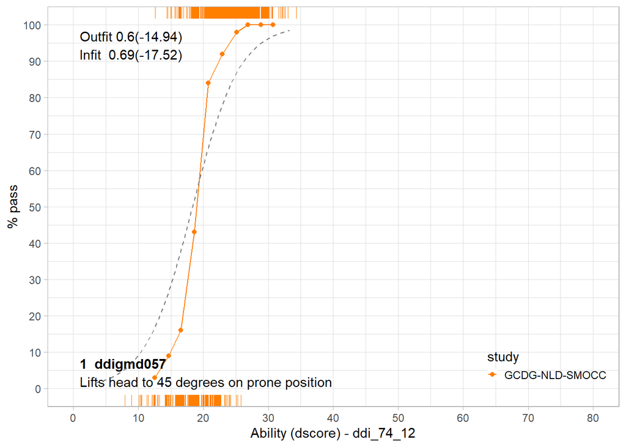

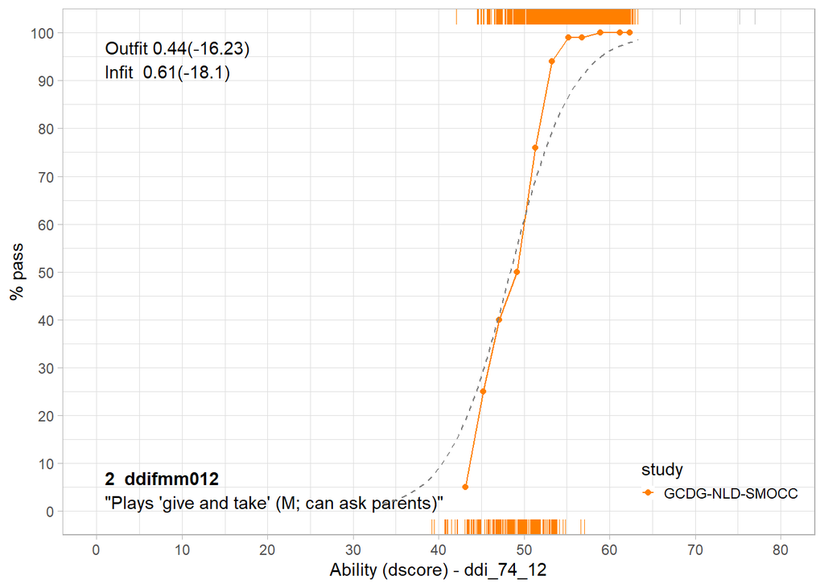

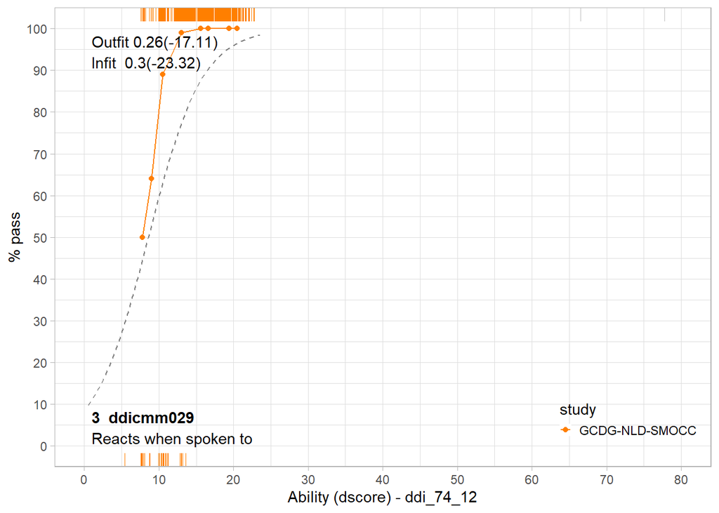

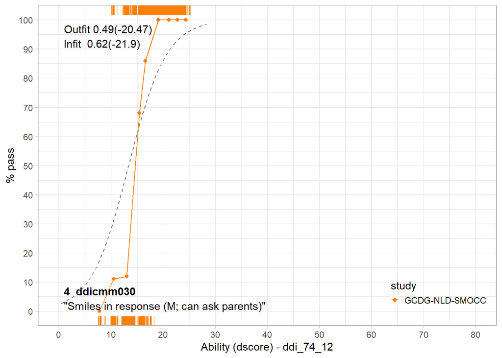

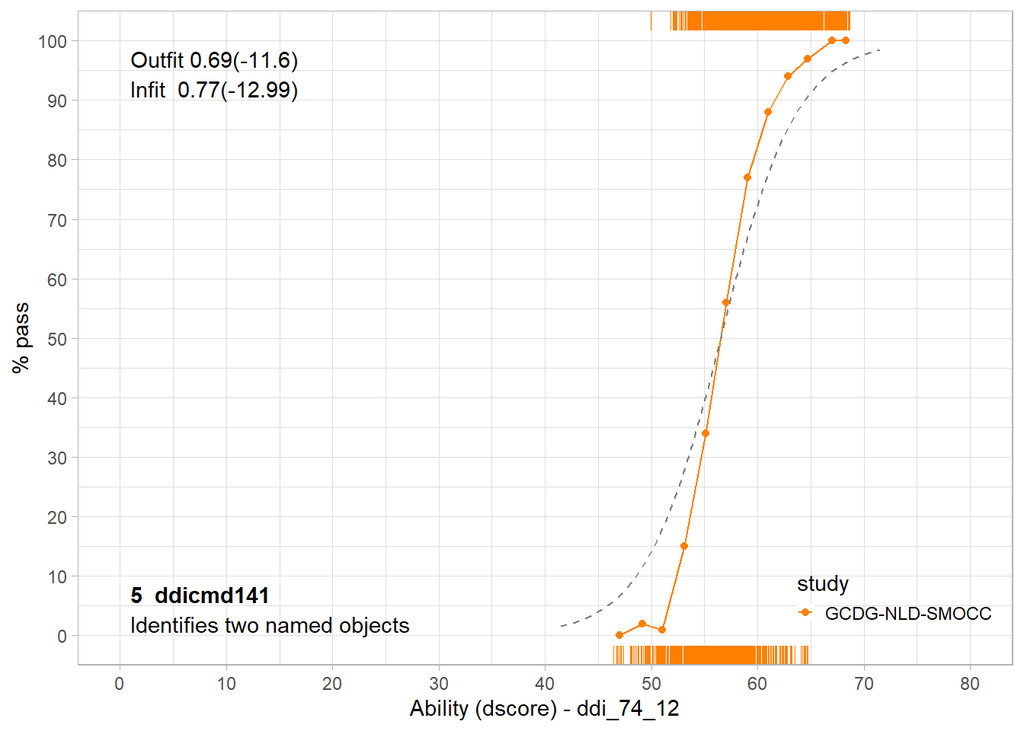

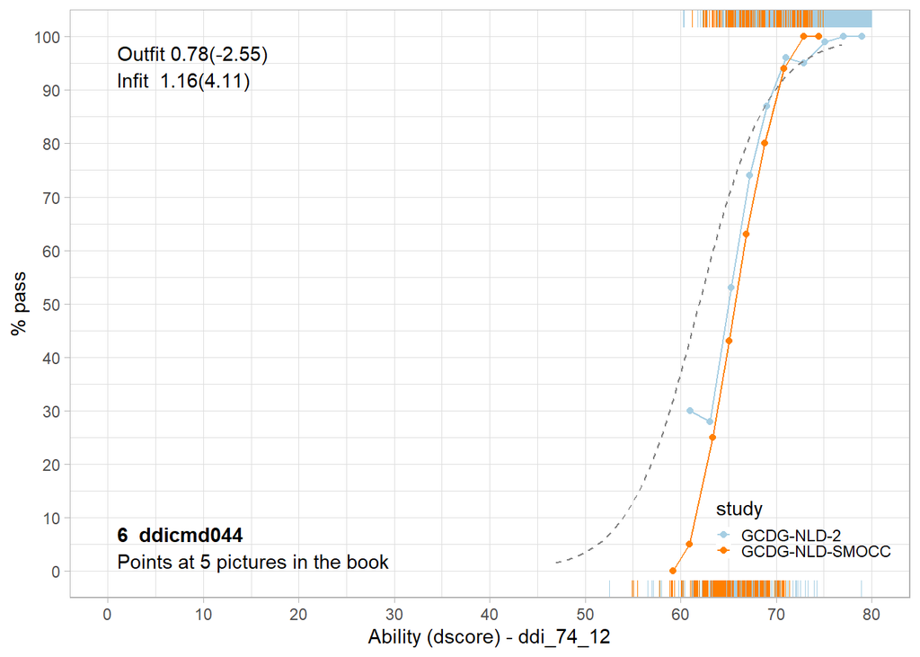

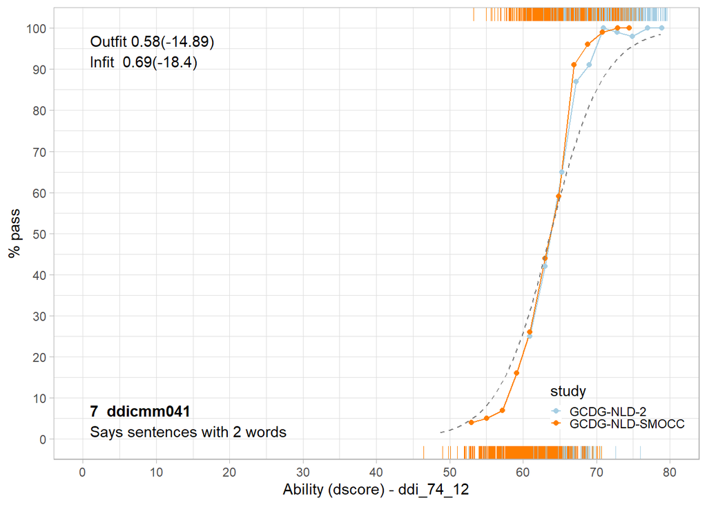

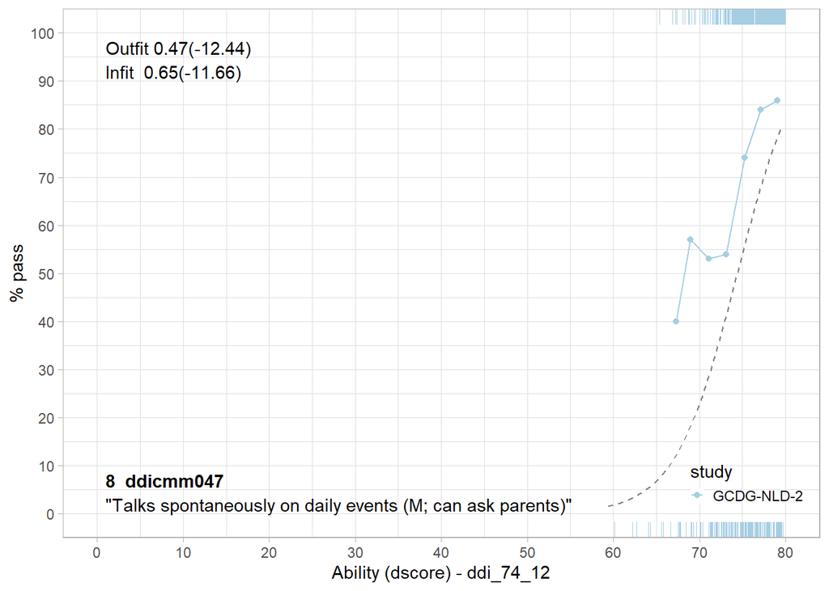

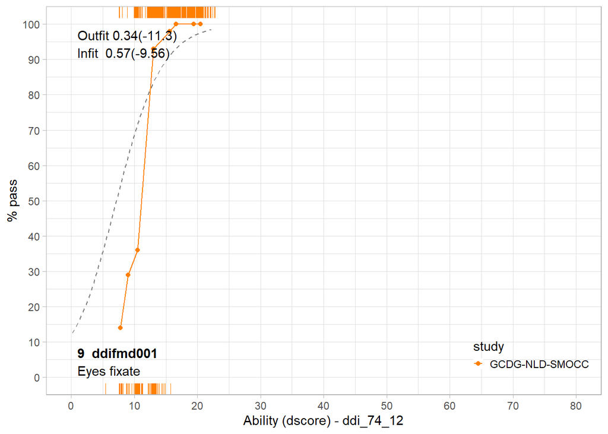

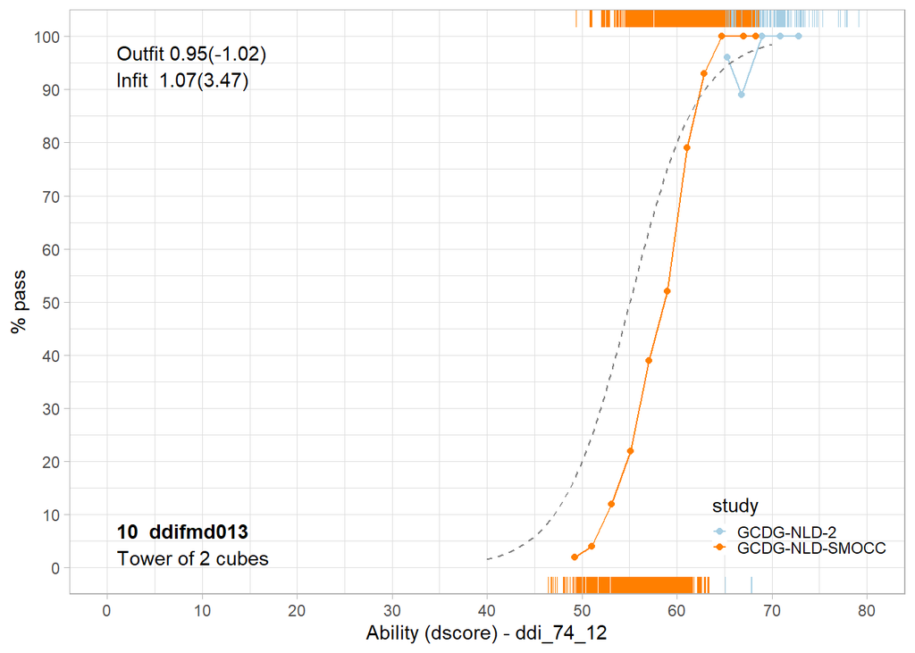

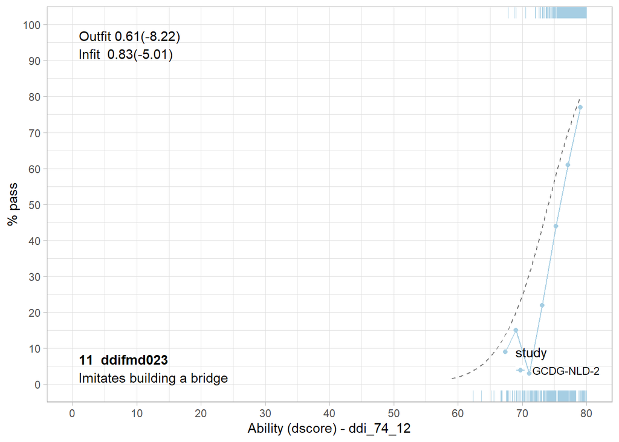

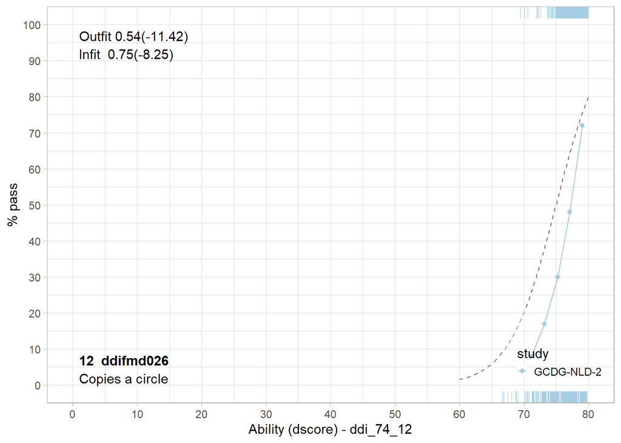

```r
icc
```

We observed discrepancies for several items: `ddicmm047`, `ddifmd013`, and `ddicmd044`.

- The parameter for `ddicmm047` appears slightly too high relative to the observed data. The DDI item label differs somewhat from the corresponding GSED item (`ddi: Talk spontaneously on daily events (M; can ask parents)` versus `gsed: Talks easily about daily events`). Therefore, this item is also released.
- For item `ddifmd013`, the parameter estimate appears somewhat lower than suggested by the observed data, despite a substantial amount of available data. The discrepancy approaches 4 D-score points. This item is also released.
- For item `ddicmd044`, the parameter estimate likewise appears substantially lower than suggested by the observed data. This pattern is observed consistently in both the SMOCC and MOM studies. Therefore, this item is also released.

**Show/hide R-code**

```r
model$item_fit |>
  dplyr::filter(item %in% c("ddifmd013", "ddicmm047", "ddicmd044"))
```

```
# A tibble: 3 × 8
  item          n outfit     qo outfit_z infit     qi infit_z
  <chr>     <int>  <dbl>  <dbl>    <dbl> <dbl>  <dbl>   <dbl>
1 ddicmd044  3226  0.781 0.0919    -2.55 1.16  0.0375    4.11
2 ddicmm047  2232  0.474 0.0530   -12.4  0.648 0.0346  -11.7
3 ddifmd013  2949  0.952 0.0468    -1.02 1.07  0.0210    3.47
```

**Show/hide R-code**

```r
ddi_fixed <- ddi_fixed[setdiff(names(ddi_fixed),c("ddifmd013", "ddicmm047", "ddicmd044"))]
```

# Model Estimation (4)

The DDI extension model is fitted using `dmetric::fit_dmodel()`. Filtered fixed DDI/GSED parameters are used to link new DDI items to the GSED2510 model and transform coefficients are used to transform to the GSED2510 scale.

**Show/hide R-code**

```r
i <- length(varlist$items)
f <- length(ddi_fixed)
model_name <- paste("ddi", i, f, sep = "_")
model_name
```

```
[1] "ddi_74_9"
```

**Show/hide R-code**

```r
model <- dmetric::fit_dmodel(
  data = data,
  varlist = varlist,
  name = model_name,
  b_fixed = ddi_fixed,
  data_package = "",
  transform = modelgsed2510$transform
)
```

# Model Diagnostics (4)

## Evaluate changes

We subsequently inspect the ICCs and item fit statistics of all released items.

**Show/hide R-code**

```r
model$data_package <- "gseddata" #hack needed to get colors of plots
icc <- dmetric::plot_p_d_item(data = data, model = model, items = c("ddigmd061", "ddifmd010", "ddifmd013", "ddicmm047", "ddicmd044"))
```

```
Item:  1 ddigmd061
Item:  2 ddifmd010
Item:  3 ddifmd013
Item:  4 ddicmm047
Item:  5 ddicmd044
```

**Show/hide R-code**

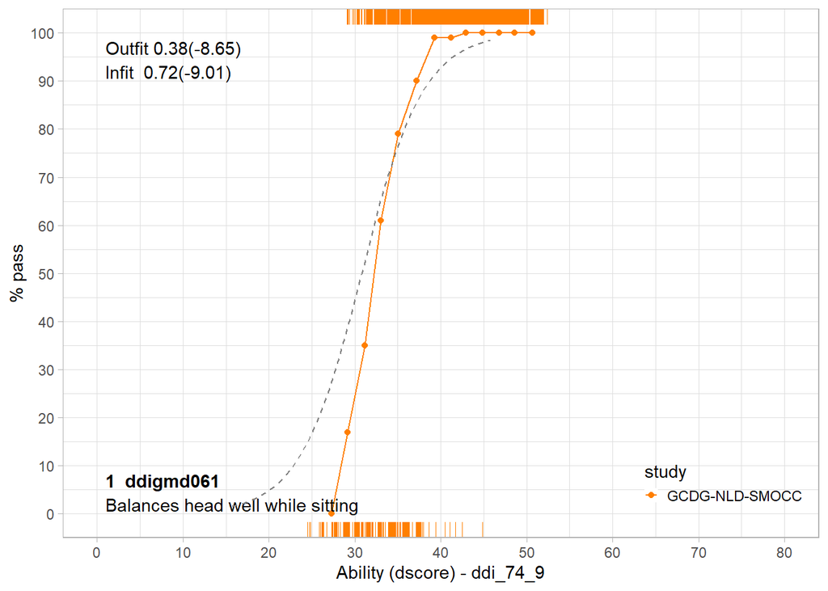

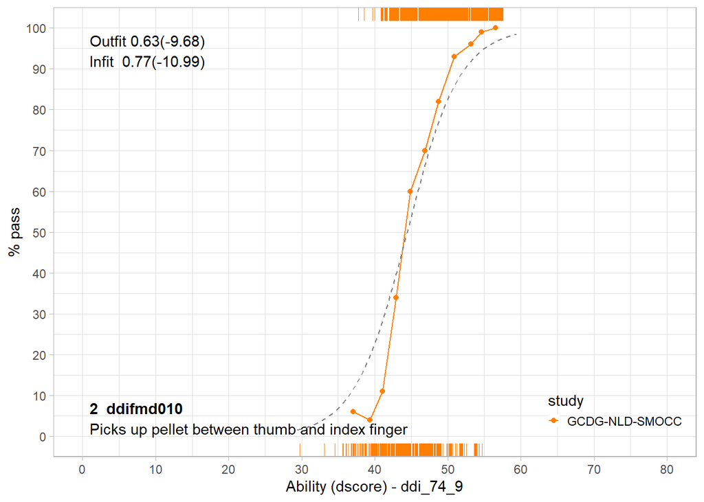

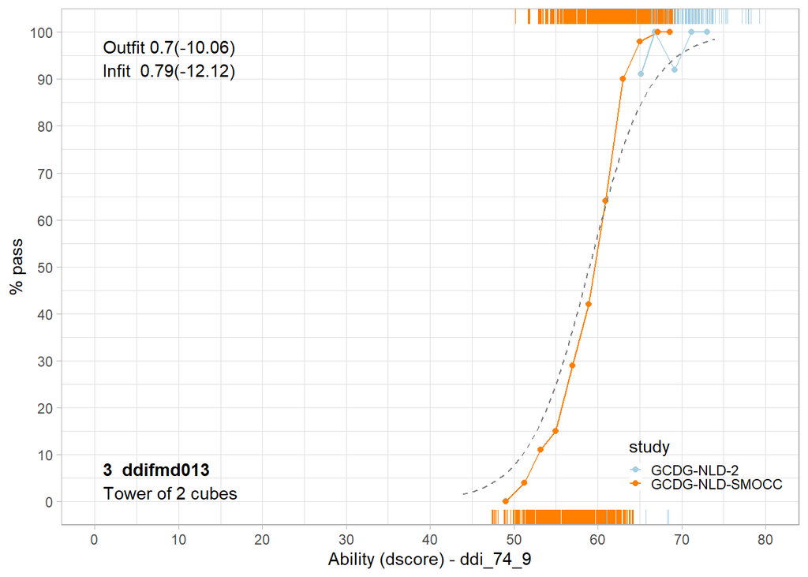

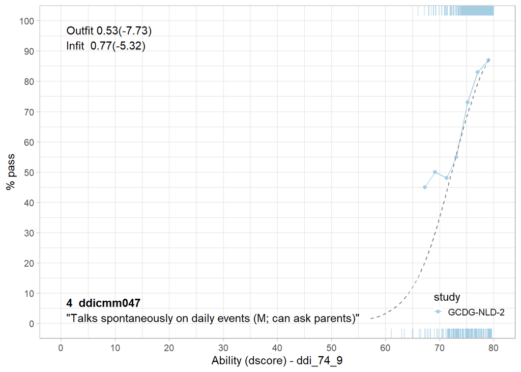

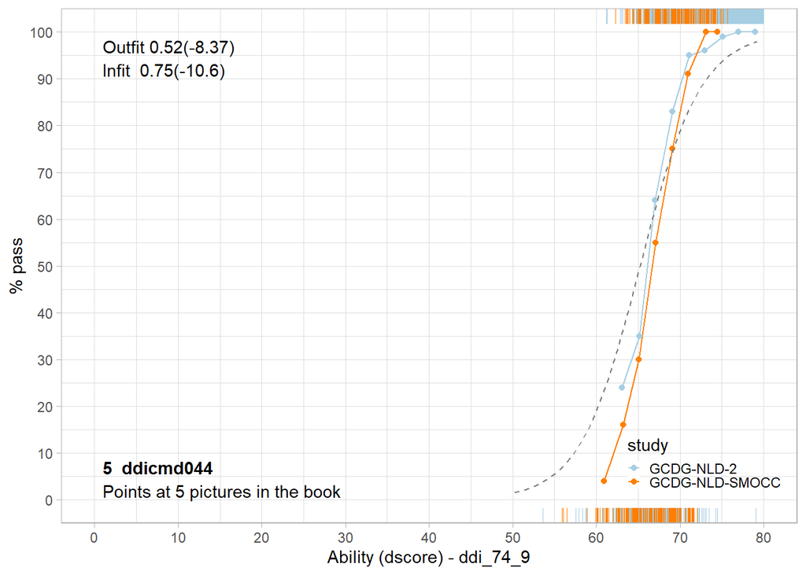

```r
icc
```

## Item Fit of all items

After model estimation, item fit was evaluated for all DDI items using infit and outfit statistics.

**Show/hide R-code**

```r
model$item_fit |>
  dplyr::filter(outfit > 1.1 | infit > 1.1)
```

```
# A tibble: 0 × 8
# ℹ 8 variables: item <chr>, n <int>, outfit <dbl>, qo <dbl>, outfit_z <dbl>,
#   infit <dbl>, qi <dbl>, infit_z <dbl>
```

> All values fall within the acceptable threshold of 1.4 (criterion used to link Bayley Scales).

## ICC of all items

We also inspect the ICCs of all items in the final model.

**Show/hide R-code**

```r
model$data_package <- "gseddata" #hack needed to get colors of plots
icc <- dmetric::plot_p_d_item(data = data, model = model, items = varlist$items)
```

```
Item:  1 ddicmm029
Item:  2 ddicmm030
Item:  3 ddicmm031
Item:  4 ddicmm033
Item:  5 ddicmm034
Item:  6 ddicmm036
Item:  7 ddicmm037
Item:  8 ddicmm039
Item:  9 ddicmm041
Item:  10 ddicmm042
Item:  11 ddicmm043
Item:  12 ddicmd044
Item:  13 ddicmm045
Item:  14 ddicmm046
Item:  15 ddicmm047
Item:  16 ddicmm048
Item:  17 ddicmd049
Item:  18 ddicmm050
Item:  19 ddicmd116
Item:  20 ddicmd136
Item:  21 ddicmd141
Item:  22 ddicmd148
Item:  23 ddifmd001
Item:  24 ddifmd002
Item:  25 ddifmd003
Item:  26 ddifmm004
Item:  27 ddifmd005
Item:  28 ddifmd007
Item:  29 ddifmd008
Item:  30 ddifmm009
Item:  31 ddifmd010
Item:  32 ddifmd011
Item:  33 ddifmm012
Item:  34 ddifmd013
Item:  35 ddifmm014
Item:  36 ddifmd015
Item:  37 ddifmm016
Item:  38 ddifmd017
Item:  39 ddifmd018
Item:  40 ddifmm019
```

[output cut: 19 more lines]

```
Item:  60 ddigmd063
Item:  61 ddigmm064
Item:  62 ddigmm065
Item:  63 ddigmm066
Item:  64 ddigmm067
Item:  65 ddigmd068
Item:  66 ddigmd069
Item:  67 ddigmd070
Item:  68 ddigmd071
Item:  69 ddigmd072
Item:  70 ddigmm073
Item:  71 ddigmd074
Item:  72 ddigmd146
Item:  73 ddigmd168
Item:  74 ddigmd268
```

**Show/hide R-code**

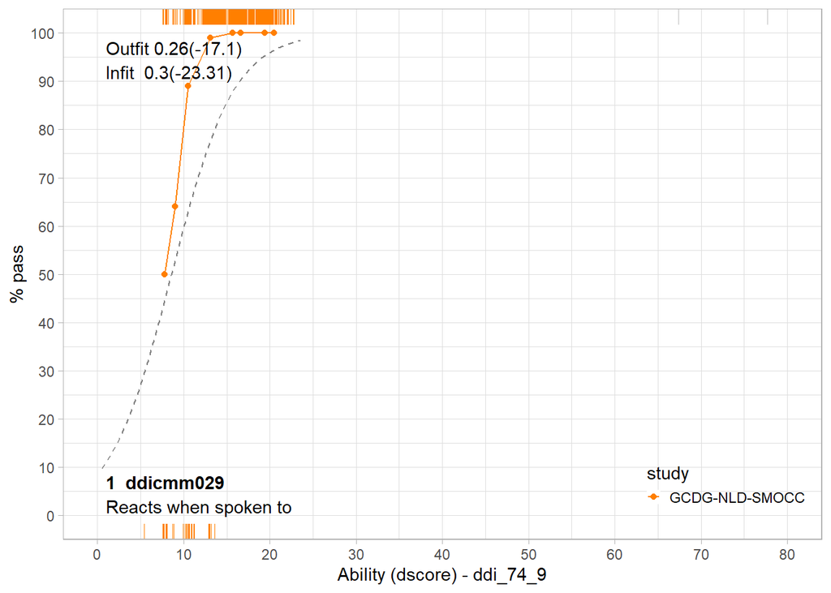

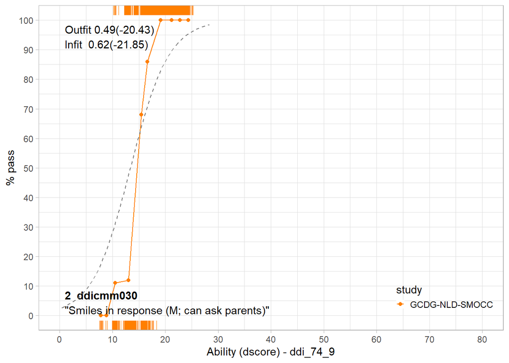

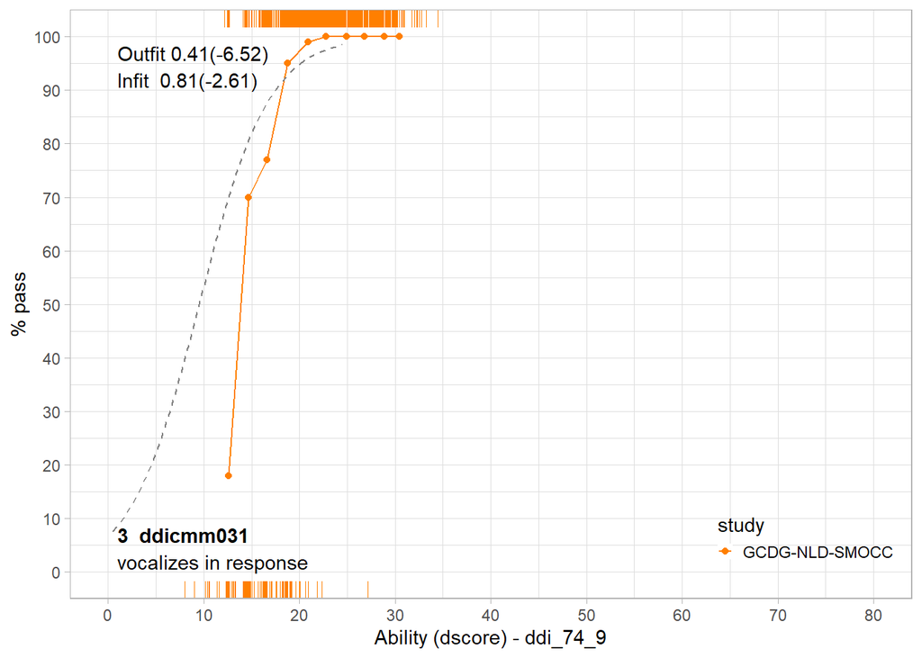

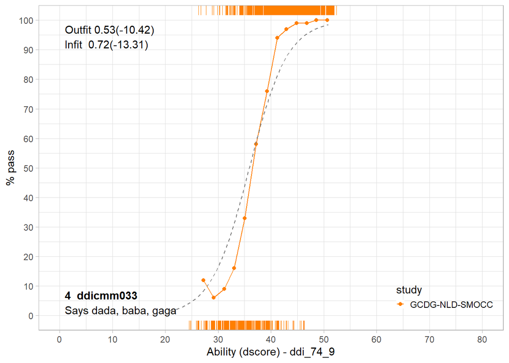

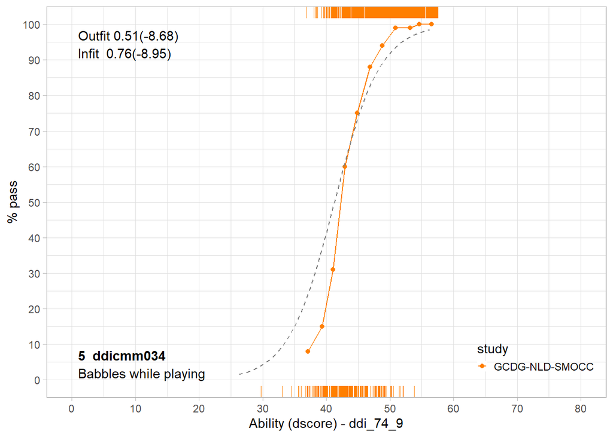

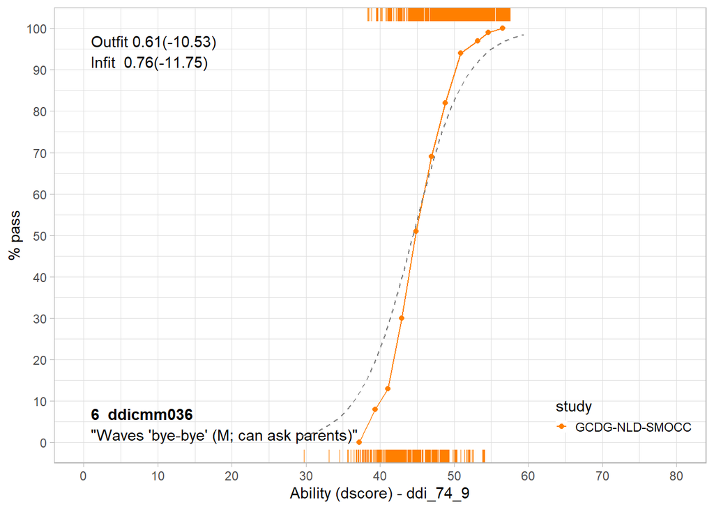

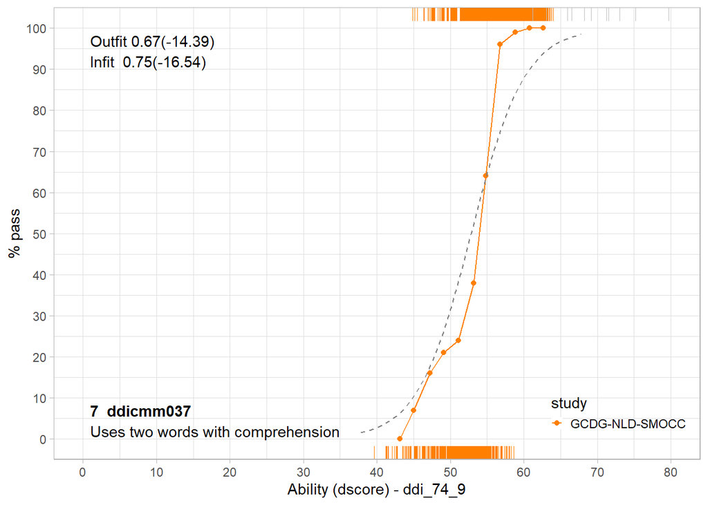

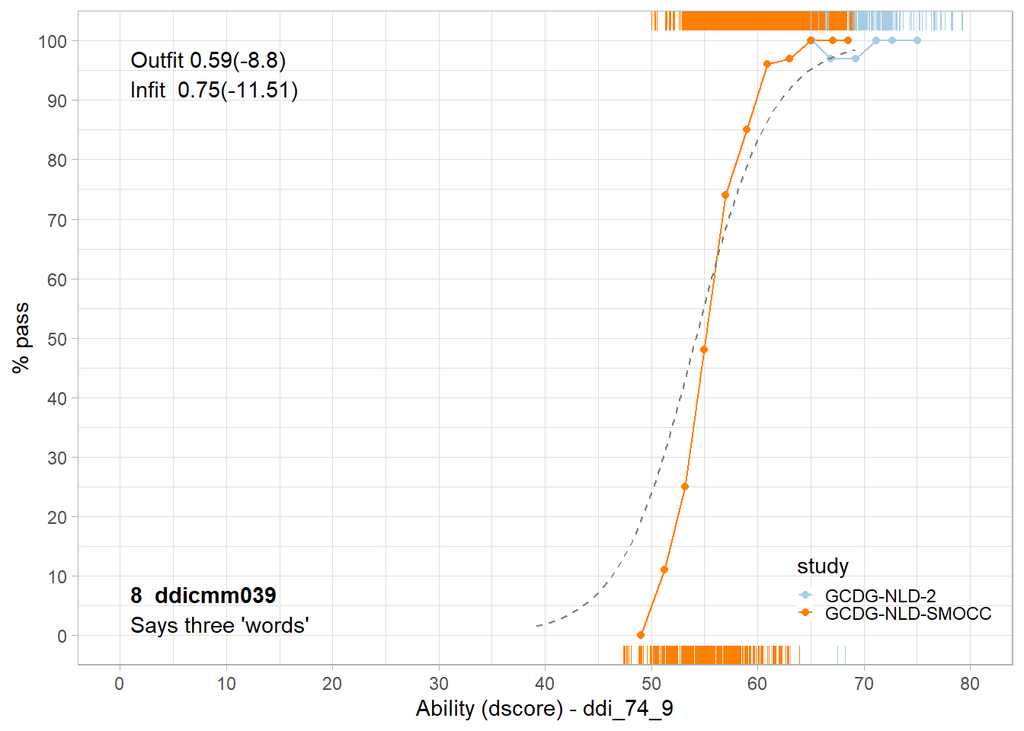

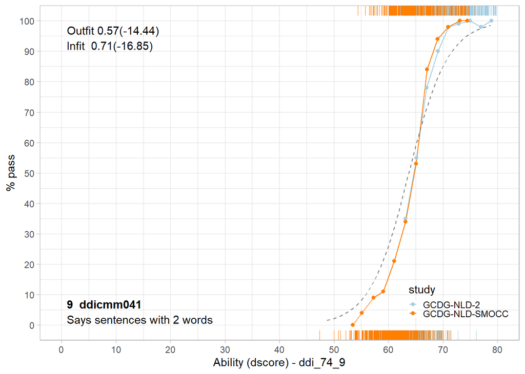

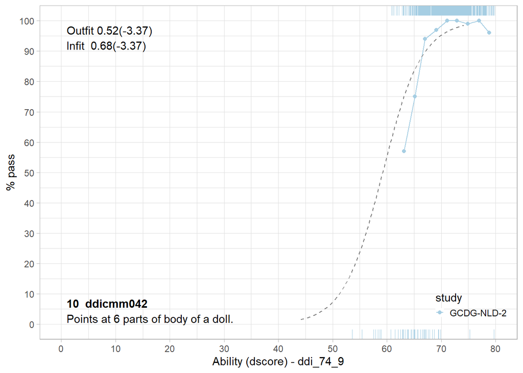

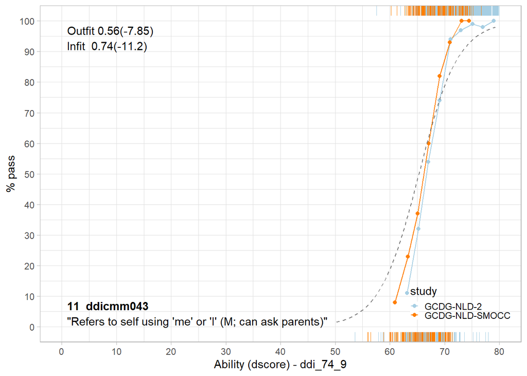

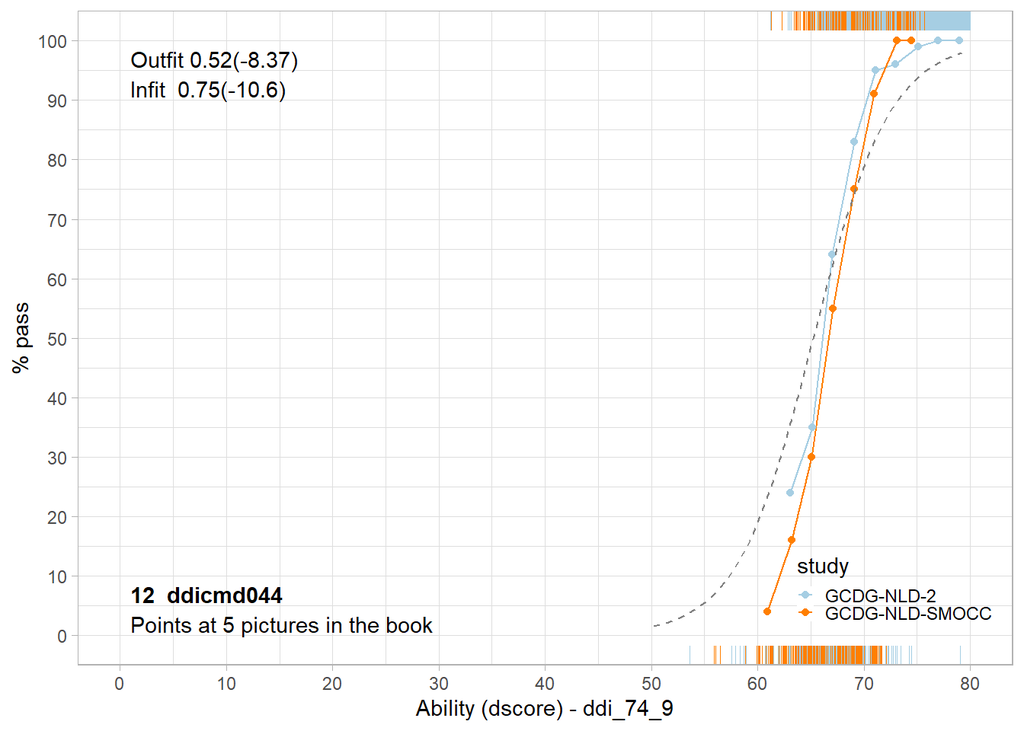

[62 more figures not shown]

```r
icc
```

# Store final model

The final model is saved together with ICC plots and D-score plots generated through `dmetric::plot_dmodel()`.

**Show/hide R-code**

```r
path <- file.path("pad", "naar", model_name)
dir.create(path, showWarnings = FALSE, recursive = TRUE)

saveRDS(model, file = file.path(path, "model.Rds"), compress = "xz")

r <- dmetric::plot_dmodel(
  data = data,
  model = model,
  path = path,
  ref_name = "preliminary_standards",
  maxy = 85,
  xbreaks = seq(0, 80, 10)
)
```

De item parameters zijn opgeslagen in `data/itembank_vwc` en dus onderdeel van `dscoreddi::itembank_vwc`.

# Comparison with the Previous D-score Calibration

To assess the impact of the update, DDI/Van Wiechen item parameters based on the earlier GSED2406 calibration were compared with those obtained under the new GSED2510 calibration.

**Show/hide R-code**

```r
library(dscoreddi)
itembank_gsed2510 <- model$itembank |>
  select(item, tau, label) |>
  mutate(decompose_itemnames(item),
         key = "gsed2510") |>
  select(key, everything())

ibcomp <- itembank_vwc |> filter(key == "gsed2406") |>
  bind_rows(itembank_gsed2510) |> pivot_wider(names_from = "key", values_from = "tau")


cor(ibcomp$gsed2406, ibcomp$gsed2510, use = "pairwise.complete.obs")
```

```
[1] 0.9901975
```

A scatter plot can be used to identify systematic shifts, outlying items, or nonlinear differences between calibrations. Some differences between the two models are expected, particularly at the lower end of the D-score scale.

**Show/hide R-code**

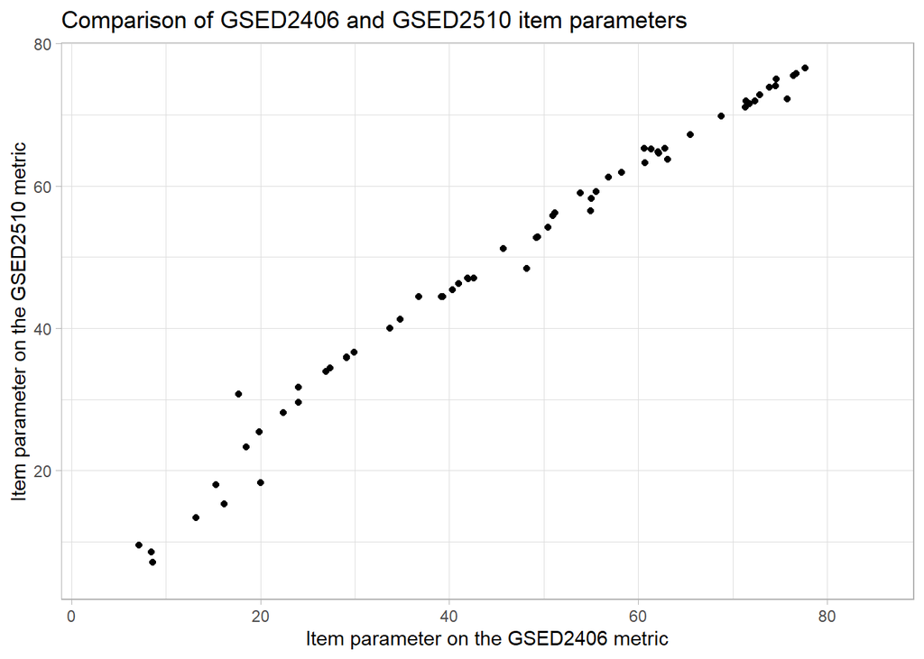

```r
ggplot(ibcomp, aes(gsed2406, gsed2510)) +
  geom_point() +
  labs(
  x = "Item parameter on the GSED2406 metric",
  y = "Item parameter on the GSED2510 metric",
  title = "Comparison of GSED2406 and GSED2510 item parameters"
)
```

The D-scores obtained under the previous model can be compared with those obtained under the current model. Correlations are high for both the D-score and DAZ. When the absolute D-scores are plotted, the new model generally yields higher D-score estimates.

**Show/hide R-code**

```r
dsc_2406 <- dscore(data = data, key = "gsed2406", population = "dutch", xname = "agedays", xunit = "days", itembank = dscoreddi::itembank_vwc)
dsc_2510 <- dscore(data = data, key = "gsed2510", population = "GSED-NLD", xname = "agedays", xunit = "days", itembank = itembank_gsed2510)

cor(dsc_2406$daz, dsc_2510$daz, use = "pairwise.complete.obs")
```

```
[1] 0.9600149
```

**Show/hide R-code**

```r
cor(dsc_2406$d, dsc_2510$d, use = "pairwise.complete.obs")
```

```
[1] 0.9969097
```

**Show/hide R-code**

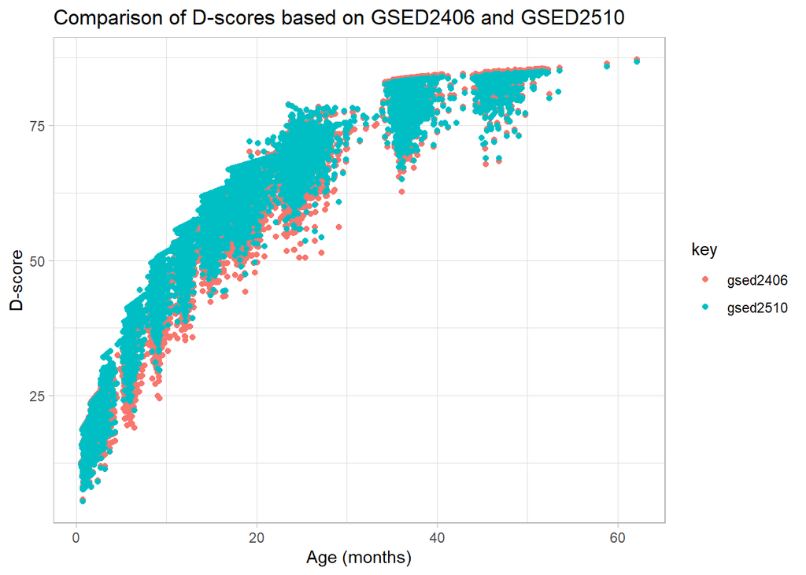

```r
dsc_df <- bind_rows(
  {dsc_2406 |> mutate(key = "gsed2406")},
  {dsc_2510 |> mutate(key = "gsed2510")}
)

ggplot(dsc_df, aes(a*12, d, group = key, color = key)) +
  geom_point() +
  labs(
  x = "Age (months)",
  y = "D-score",
  title = "Comparison of D-scores based on GSED2406 and GSED2510"
)
```

Age standardization (DAZ) is currently based on different reference populations across the two models. For the GSED2406 model, standardization is based on the same data used for calibration. For the GSED2510 model, standardization is based on Dutch children who completed the GSED. As a result, the comparison cannot be interpreted as a fully one-to-one comparison.

In the future, we would like to create a GSED2510 reference based on all Dutch data currently available to us.

**Show/hide R-code**

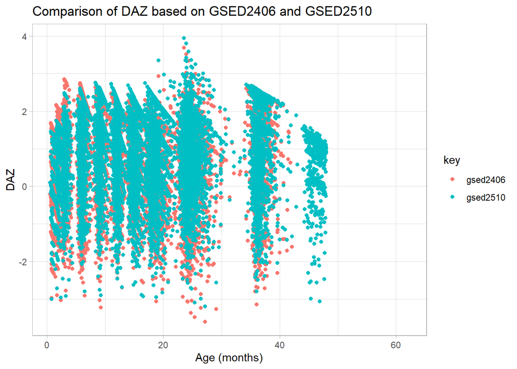

```r
ggplot(dsc_df, aes(a*12, daz, group = key, color = key)) +
  geom_point() +
  labs(
  x = "Age (months)",
  y = "DAZ",
  title = "Comparison of DAZ based on GSED2406 and GSED2510"
)
```

# Preliminary Interpretation

Based on the current pipeline, it is technically feasible to extend the GSED2510 model with DDI/Van Wiechen items. By using DDI items that are directly linked to existing GSED items, new item parameters can be placed on the GSED2510 metric. The resulting item parameters provide the basis for calculating D-scores in Dutch preventive child healthcare datasets.

# Reproducibility

**Show/hide R-code**